# reading_data_from_the_web

Fenglin Xie

2025-10-24

```r
library(tidyverse)
```

```r
knitr::opts_chunk$set(
  fig.width = 6,
  fig.asp = .6,
  out.width = "90%"
)

theme_set(theme_minimal() + theme(legend.position = "bottom"))

options(
  ggplot2.continuous.colour = "viridis",
  ggplot2.continuous.fill = "viridis"
)

scale_colour_discrete = scale_colour_viridis_d
scale_fill_discrete = scale_fill_viridis_d
```

##如何从网站上获取data

load key packages

```r
library(rvest)
library(httr)
```

import NSDUH data from the web ##把网站上的所有信息都导入到R ##如果网站没有了，那这些代码就跑不了了，为了防止这个情况，你需要把数据导出然后保存到本地

```r
url = "https://samhda.s3-us-gov-west-1.amazonaws.com/s3fs-public/field-uploads/2k15StateFiles/NSDUHsaeShortTermCHG2015.htm"

drug_use_html = read_html(url)
```

This is an “easy” case

##`html_table()`–获取网站上的所有table（most common CSS tag）

####CSS(Cascading Style Sheets,层叠样式表)是网页设计中用于控制布局和外观的强大工具。tag（选择器）是CSS的核心,它允许我们精确地定位HTML元素并应用样式

```r
drug_use_html |>
  html_table()
```

```
## [[1]]
## # A tibble: 57 × 16
##    State     `12+(2013-2014)` `12+(2014-2015)` `12+(P Value)` `12-17(2013-2014)`
##    <chr>     <chr>            <chr>            <chr>          <chr>
##  1 "NOTE: S… "NOTE: State an… "NOTE: State an… "NOTE: State … "NOTE: State and …
##  2 "Total U… "12.90a"         "13.36"          "0.002"        "13.28b"
##  3 "Northea… "13.88a"         "14.66"          "0.005"        "13.98"
##  4 "Midwest" "12.40b"         "12.76"          "0.082"        "12.45"
##  5 "South"   "11.24a"         "11.64"          "0.029"        "12.02"
##  6 "West"    "15.27"          "15.62"          "0.262"        "15.53a"
##  7 "Alabama" "9.98"           "9.60"           "0.426"        "9.90"
##  8 "Alaska"  "19.60a"         "21.92"          "0.010"        "17.30"
##  9 "Arizona" "13.69"          "13.12"          "0.364"        "15.12"
## 10 "Arkansa… "11.37"          "11.59"          "0.678"        "12.79"
## # ℹ 47 more rows
## # ℹ 11 more variables: `12-17(2014-2015)` <chr>, `12-17(P Value)` <chr>,
## #   `18-25(2013-2014)` <chr>, `18-25(2014-2015)` <chr>, `18-25(P Value)` <chr>,
## #   `26+(2013-2014)` <chr>, `26+(2014-2015)` <chr>, `26+(P Value)` <chr>,
## #   `18+(2013-2014)` <chr>, `18+(2014-2015)` <chr>, `18+(P Value)` <chr>
##
## [[2]]
## # A tibble: 57 × 16
##    State     `12+(2013-2014)` `12+(2014-2015)` `12+(P Value)` `12-17(2013-2014)`
##    <chr>     <chr>            <chr>            <chr>          <chr>
##  1 "NOTE: S… "NOTE: State an… "NOTE: State an… "NOTE: State … "NOTE: State and …
##  2 "Total U… "7.96a"          "8.34"           "0.001"        "7.22"
##  3 "Northea… "8.58a"          "9.28"           "0.001"        "7.68"
##  4 "Midwest" "7.50a"          "7.92"           "0.009"        "6.64"
##  5 "South"   "6.74a"          "7.02"           "0.044"        "6.31"
##  6 "West"    "9.84"           "10.08"          "0.324"        "8.85"
##  7 "Alabama" "5.57"           "5.35"           "0.510"        "4.98"
##  8 "Alaska"  "11.85a"         "14.38"          "0.002"        "9.19"
##  9 "Arizona" "8.80"           "8.51"           "0.570"        "8.30"
## 10 "Arkansa… "6.70"           "7.17"           "0.240"        "6.22"
## # ℹ 47 more rows
## # ℹ 11 more variables: `12-17(2014-2015)` <chr>, `12-17(P Value)` <chr>,
## #   `18-25(2013-2014)` <chr>, `18-25(2014-2015)` <chr>, `18-25(P Value)` <chr>,
## #   `26+(2013-2014)` <chr>, `26+(2014-2015)` <chr>, `26+(P Value)` <chr>,
## #   `18+(2013-2014)` <chr>, `18+(2014-2015)` <chr>, `18+(P Value)` <chr>
##
```

[output cut: 236 more lines]

```
##    <chr>     <chr>            <chr>            <chr>          <chr>
##  1 "NOTE: S… "NOTE: State an… "NOTE: State an… "NOTE: State … "NOTE: State and …
##  2 "Total U… "6.63"           "6.64"           "0.915"        "11.01a"
##  3 "Northea… "6.66"           "6.82"           "0.458"        "10.63a"
##  4 "Midwest" "6.81"           "6.87"           "0.736"        "10.81a"
##  5 "South"   "6.47"           "6.52"           "0.750"        "10.77a"
##  6 "West"    "6.67"           "6.47"           "0.353"        "11.82a"
##  7 "Alabama" "6.85"           "6.81"           "0.948"        "10.74"
##  8 "Alaska"  "6.57"           "6.73"           "0.770"        "9.92a"
##  9 "Arizona" "7.32"           "6.77"           "0.362"        "13.23"
## 10 "Arkansa… "7.31"           "7.78"           "0.446"        "11.95"
## # ℹ 47 more rows
## # ℹ 8 more variables: `12-17(2014-2015)` <chr>, `12-17(P Value)` <chr>,
## #   `18-25(2013-2014)` <chr>, `18-25(2014-2015)` <chr>, `18-25(P Value)` <chr>,
## #   `26+(2013-2014)` <chr>, `26+(2014-2015)` <chr>, `26+(P Value)` <chr>
```

一共15个table，若只要第一个table

```r
drug_use_html |>
  html_table() |>
  first()
```

```
## # A tibble: 57 × 16
##    State     `12+(2013-2014)` `12+(2014-2015)` `12+(P Value)` `12-17(2013-2014)`
##    <chr>     <chr>            <chr>            <chr>          <chr>
##  1 "NOTE: S… "NOTE: State an… "NOTE: State an… "NOTE: State … "NOTE: State and …
##  2 "Total U… "12.90a"         "13.36"          "0.002"        "13.28b"
##  3 "Northea… "13.88a"         "14.66"          "0.005"        "13.98"
##  4 "Midwest" "12.40b"         "12.76"          "0.082"        "12.45"
##  5 "South"   "11.24a"         "11.64"          "0.029"        "12.02"
##  6 "West"    "15.27"          "15.62"          "0.262"        "15.53a"
##  7 "Alabama" "9.98"           "9.60"           "0.426"        "9.90"
##  8 "Alaska"  "19.60a"         "21.92"          "0.010"        "17.30"
##  9 "Arizona" "13.69"          "13.12"          "0.364"        "15.12"
## 10 "Arkansa… "11.37"          "11.59"          "0.678"        "12.79"
## # ℹ 47 more rows
## # ℹ 11 more variables: `12-17(2014-2015)` <chr>, `12-17(P Value)` <chr>,
## #   `18-25(2013-2014)` <chr>, `18-25(2014-2015)` <chr>, `18-25(P Value)` <chr>,
## #   `26+(2013-2014)` <chr>, `26+(2014-2015)` <chr>, `26+(P Value)` <chr>,
## #   `18+(2013-2014)` <chr>, `18+(2014-2015)` <chr>, `18+(P Value)` <chr>
```

指定需要第x个–`nth()`

```r
drug_use_html |>
  html_table() |>
  nth(7)
```

```
## # A tibble: 57 × 4
##    State    Alcohol Use inPast M…¹ Alcohol Use inPast M…² Alcohol Use inPast M…³
##    <chr>    <chr>                  <chr>                  <chr>
##  1 "NOTE: … "NOTE: State and cens… "NOTE: State and cens… "NOTE: State and cens…
##  2 "Total … "22.76a"               "21.57"                "0.000"
##  3 "Northe… "26.11"                "25.98"                "0.792"
##  4 "Midwes… "23.73a"               "22.00"                "0.000"
##  5 "South"  "20.68a"               "19.66"                "0.010"
##  6 "West"   "22.73a"               "21.01"                "0.000"
##  7 "Alabam… "19.25"                "18.19"                "0.305"
##  8 "Alaska" "21.47b"               "23.91"                "0.058"
##  9 "Arizon… "22.01a"               "19.25"                "0.009"
## 10 "Arkans… "18.07"                "16.65"                "0.106"
## # ℹ 47 more rows
## # ℹ abbreviated names: ¹`Alcohol Use inPast Month(2013-2014)`,
## #   ²`Alcohol Use inPast Month(2014-2015)`,
## #   ³`Alcohol Use inPast Month(P Value)`
```

table的底部备注会被放在table的第一行，现在我们想要去掉这一行 ##filter是针对variable，slice是针对rows

```r
ndsuh_df =
  drug_use_html |>
  html_table() |>
  first() |>
  slice(-1)
```

现在的数据还非常不整洁，数据显示为chr类型，行头中的12+代表的是年龄，（2013-2014）代表的是年份

slightly harder case

```r
url = "https://www.imdb.com/list/ls070150896/"

sw_html =
  read_html(url)
```

##only extract the features that we are interested in–CSS selector

Now pull out elements of the html that I care about 从网页抓取所需信息

```r
title_vec =
  sw_html |>
  html_elements(".ipc-title-link-wrapper .ipc-title__text--reduced") |>
  html_text()

metascore_vec =
  sw_html |>
  html_elements(".metacritic-score-box") |>
  html_text()

runtime_vec =
  sw_html |>
  html_elements(".dli-title-metadata-item:nth-child(2)") |>
  html_text()

sw_df =
  tibble(
    title = title_vec,
    metascore = metascore_vec,
    runtime = runtime_vec
  )
```

## APIs

### get data using an API

Get the NYC water consumption dataset ##通过HTTP package ##“parsed”–猜一猜数据应该是什么形式，然后show it in that way

```r
nyc_water_df =
  GET("https://data.cityofnewyork.us/resource/ia2d-e54m.csv") |>
  content("parsed")
```

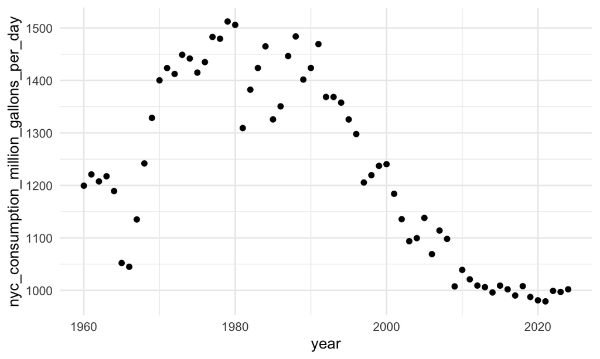

```r
nyc_water_df |>
  ggplot(aes(x = year, y = nyc_consumption_million_gallons_per_day)) +
  geom_point()
```

Access BRFSS

##如果需要 app token，则去该网站找到token，按照一下操作即可

##因为数据集实在太大了，我不想每次knit都重新跑一遍他(完成一遍full API call)，所以`eval=FALSE`

```r
brfss_df =
  GET(
    "https://chronicdata.cdc.gov/api/v3/views/acme-vg9e/query.csv",
    query = list("app_token" = "复制你的token到这里")
  ) |>
  content("parsed")
```

Look at Pokemon data ##这些数据太complicated，无法快速使用“parsed” ##`poke[[1]]`查看Pokemon的first element

##需要进行很多操作去 organize the output into a dataframe

```r
poke =
  GET("http://pokeapi.co/api/v2/pokemon/1") |>
  content()

poke[[1]]
```

```
## [[1]]
## [[1]]$ability
## [[1]]$ability$name
## [1] "overgrow"
##
## [[1]]$ability$url
## [1] "https://pokeapi.co/api/v2/ability/65/"
##
##
## [[1]]$is_hidden
## [1] FALSE
##
## [[1]]$slot
## [1] 1
##
##
## [[2]]
## [[2]]$ability
## [[2]]$ability$name
## [1] "chlorophyll"
##
## [[2]]$ability$url
## [1] "https://pokeapi.co/api/v2/ability/34/"
##
##
## [[2]]$is_hidden
## [1] TRUE
##
## [[2]]$slot
## [1] 3
```